# Spotify EDA of Personal Music Taste

Every year, Spotify releases a ['Spotify Wrapped'](https://newsroom.spotify.com/2021-12-01/the-wait-is-over-your-spotify-2021-wrapped-is-here/) tailored to each user's listening experience. But they only release so much information to the user and it got me curious about the ins and outs of my own music listening history.

## Spotipy Initalization

In order to perform exploratory data analysis (EDA), I need to gather the saved songs from my spotify library. Saved songs are classified as those that received a 'like' which is in the shape of a heart on Spotify.

I achieve this using a [Spotipy](https://spotipy.readthedocs.io/en/master/) which is a python library for the [Spotify API](https://developer.spotify.com/documentation/web-api/quick-start/)

*Note: if you're interested in using either of these yourself, you can see my resources_and_setup file*

```python
# import dependencies for authentication
import os
import spotipy
from spotipy.oauth2 import SpotifyClientCredentials
from spotipy.oauth2 import SpotifyOAuth
from dotenv import load_dotenv
```

```python
# import dependencies for eda
import os
import numpy as np
import pandas as pd

import seaborn as sns
import plotly.express as px
import matplotlib.pyplot as plt
%matplotlib inline

from sklearn.cluster import KMeans
from sklearn.preprocessing import StandardScaler
from sklearn.pipeline import Pipeline
from sklearn.manifold import TSNE
from sklearn.decomposition import PCA
from sklearn.metrics import euclidean_distances
from scipy.spatial.distance import cdist

import warnings
warnings.filterwarnings("ignore")
```

*tip: if you see `os.getenv('some variable name'))`, that means I'm accessing an environmental variable that I set to keep my credentials private*

```python
# set and load environmental variables
load_dotenv()

SPOTIPY_CLIENT_ID = os.getenv('SPOTIPY_CLIENT_ID')
SPOTIPY_CLIENT_SECRET = os.getenv('SPOTIPY_CLIENT_SECRET')
SPOTIPY_REDIRECT_URI = os.getenv('SPOTIPY_REDIRECT_URI')

# load the spotipy manager
sp = spotipy.Spotify(auth_manager=SpotifyClientCredentials(client_id=SPOTIPY_CLIENT_ID,
                                                           client_secret=os.environ.get(SPOTIPY_CLIENT_SECRET)))
```

```python
# set the scope and user name
scope = 'user-library-read'
sp_username = os.getenv('SP_USERNAME')
```

```python
token = spotipy.util.prompt_for_user_token(sp_username, scope)

# make sure that username token exists
if token:
    spotipy_obj = spotipy.Spotify(auth=token)
    saved_tracks_resp = spotipy_obj.current_user_saved_tracks(limit=50)
else:
    print('Couldn\'t get token for that username')

# get the total number of tracks in my 'liked songs'
number_of_tracks = saved_tracks_resp['total']
print('%d tracks' % number_of_tracks)

# select which features to get
def save_only_some_fields(track_response):
    return {
        'id': str(track_response['track']['id']),
        'name': str(track_response['track']['name']),
        'artists': [artist['name'] for artist in track_response['track']['artists']],
        'duration_ms': track_response['track']['duration_ms'],
        'popularity': track_response['track']['popularity'],
        'added_at': track_response['added_at']
    }

# create a list of the tracks in my 'liked songs'
tracks = [save_only_some_fields(track) for track in saved_tracks_resp['items']]

# iterate through tracks list
while saved_tracks_resp['next']:
    saved_tracks_resp = spotipy_obj.next(saved_tracks_resp)
    tracks.extend([save_only_some_fields(track) for track in saved_tracks_resp['items']])
```

```
4677 tracks
```

## Clean Liked Songs Dataset

```python
# create a dataframe of the songs in my library
liked_songs = pd.DataFrame(tracks)
pd.set_option('display.max_rows', len(tracks))
```

```python
liked_songs['artists'] = liked_songs['artists'].apply(lambda artists: artists[0])

# change the duration to seconds
liked_songs['duration_ms'] = liked_songs['duration_ms'].apply(lambda duration: duration/1000)
# rename duration from ms (milliseconds) to s (seconds)
liked_songs = liked_songs.rename(columns = {'duration_ms':'duration_s'})
```

```python
# print the first five rows of the dataset
liked_songs.head(5)
```

|  | id | name | artists | duration_s | popularity | added_at |
| --- | --- | --- | --- | --- | --- | --- |
| 0 | 5GUYJTQap5F3RDQiCOJhrS | Self Control | Frank Ocean | 249.667 | 76 | 2022-10-08T03:33:49Z |
| 1 | 7lagLMBTqqOkta5eqRfNXc | Every Beginning Ends | Noah Cyrus | 150.491 | 61 | 2022-10-08T03:33:47Z |
| 2 | 1NZLDZsqmvMVcZ02VT7ocP | Heaven | Bazzi | 153.391 | 67 | 2022-10-08T03:33:36Z |
| 3 | 252G7yirQ4pXj6ZD4T9R2W | Mona Lisa, Mona Lisa | FINNEAS | 172.111 | 64 | 2022-10-08T03:33:35Z |
| 4 | 4MXE6VCvTsQitHWrAxj7Kg | Maple Syrup | The Backseat Lovers | 243.529 | 72 | 2022-10-08T03:33:33Z |

#### Add Audio Features

```python
# create an empty dictionary for the audio features
audio_features = {}

# for the ids in our dataset, find the audio feature values
for idd in liked_songs['id'].tolist():
    audio_features[idd] = spotipy_obj.audio_features(idd)[0]

# create new columns acousticness, speechiness, key, etc to represent the audio features
# with the applied values for each song
liked_songs['acousticness'] = liked_songs['id'].apply(lambda idd: audio_features[idd]['acousticness'])
liked_songs['speechiness'] = liked_songs['id'].apply(lambda idd: audio_features[idd]['speechiness'])
liked_songs['key'] = liked_songs['id'].apply(lambda idd: str(audio_features[idd]['key']))
liked_songs['liveness'] = liked_songs['id'].apply(lambda idd: audio_features[idd]['liveness'])
liked_songs['instrumentalness'] = liked_songs['id'].apply(lambda idd: audio_features[idd]['instrumentalness'])
liked_songs['energy'] = liked_songs['id'].apply(lambda idd: audio_features[idd]['energy'])
liked_songs['tempo'] = liked_songs['id'].apply(lambda idd: audio_features[idd]['tempo'])
liked_songs['time_signature'] = liked_songs['id'].apply(lambda idd: audio_features[idd]['time_signature'])
liked_songs['loudness'] = liked_songs['id'].apply(lambda idd: audio_features[idd]['loudness'])
liked_songs['danceability'] = liked_songs['id'].apply(lambda idd: audio_features[idd]['danceability'])
liked_songs['valence'] = liked_songs['id'].apply(lambda idd: audio_features[idd]['valence'])
```

```python
# print the first 5 rows in the dataset again
liked_songs.head(5)
```

|  | id | name | artists | duration_s | popularity | added_at | acousticness | speechiness | key | liveness | instrumentalness | energy | tempo | time_signature | loudness | danceability | valence |
| --- | --- | --- | --- | --- | --- | --- | --- | --- | --- | --- | --- | --- | --- | --- | --- | --- | --- |
| 0 | 5GUYJTQap5F3RDQiCOJhrS | Self Control | Frank Ocean | 249.667 | 76 | 2022-10-08T03:33:49Z | 0.7680 | 0.0321 | 8 | 0.3690 | 0.000000 | 0.210 | 80.099 | 4 | -10.426 | 0.581 | 0.452 |
| 1 | 7lagLMBTqqOkta5eqRfNXc | Every Beginning Ends | Noah Cyrus | 150.491 | 61 | 2022-10-08T03:33:47Z | 0.6300 | 0.0277 | 3 | 0.1090 | 0.000042 | 0.360 | 116.944 | 3 | -9.930 | 0.627 | 0.390 |
| 2 | 1NZLDZsqmvMVcZ02VT7ocP | Heaven | Bazzi | 153.391 | 67 | 2022-10-08T03:33:36Z | 0.1400 | 0.0350 | 5 | 0.0560 | 0.000004 | 0.575 | 114.986 | 4 | -5.515 | 0.798 | 0.683 |
| 3 | 252G7yirQ4pXj6ZD4T9R2W | Mona Lisa, Mona Lisa | FINNEAS | 172.111 | 64 | 2022-10-08T03:33:35Z | 0.0252 | 0.0441 | 0 | 0.5810 | 0.023000 | 0.521 | 125.032 | 4 | -6.844 | 0.742 | 0.646 |
| 4 | 4MXE6VCvTsQitHWrAxj7Kg | Maple Syrup | The Backseat Lovers | 243.529 | 72 | 2022-10-08T03:33:33Z | 0.0447 | 0.0582 | 2 | 0.0778 | 0.053300 | 0.526 | 153.000 | 3 | -9.703 | 0.543 | 0.384 |

#### Add Genres

```python
# define the function to search for the genre per artist
def get_genres(artist, spotipy_obj):
    response = spotipy_obj.search(q='artist:' + artist, type='artist')['artists']['items']
    return response[0]['genres'] if response else []
```

```python
# test out the function
get_genres('Noah Cyrus', spotipy_obj)
```

```
['pop', 'post-teen pop']
```

Okay, that worked so we'll perform it on our whole dataset

```python
# get the unique artists from liked_songs
artists = list(liked_songs.artists.unique())

# create empty list for genres
genres = []
```

```python
# iterate through list of artist names and append the genres to the genre list
for artist in artists:
    genres.append(get_genres(artist, spotipy_obj))
```

If we print out our genres list, we can see that it is in fact a list of lists because most artists are associate witha more than one genre

```python
genres[:15]
```

```
[['hip hop', 'lgbtq+ hip hop', 'neo soul', 'pop'],
 ['pop', 'post-teen pop'],
 ['dance pop', 'electropop', 'pop'],
 ['alt z', 'electropop', 'la indie', 'pop'],
 ['indie pop', 'modern rock', 'slc indie'],
 ['boy band', 'dance pop', 'pop', 'post-teen pop', 'uk pop'],
 ['piano rock', 'pop', 'pop rock'],
 ['bolero', 'latin pop'],
 ['alt z'],
 ['alt z', 'electropop', 'pop'],
 ['dance pop', 'edm', 'pop dance', 'pop edm', 'tropical house'],
 ['electropop', 'pop'],
 ['alternative r&b',
  'dance pop',
  'hip pop',
  'neo soul',
  'pop',
  'pop r&b',
  'r&b',
  'rap',
  'urban contemporary'],
 ['other'],
 ['other']]
```

```python
# we'll create a copy of our genres list because the code following will remove them as they are added to the dictionary
genres_copy = genres.copy()
```

```python
# empty dictionary for the artists and respective genres
artists_genres = {}

# iterate through
for key in artists:
    for value in genres:
        artists_genres[key] = value
        genres.remove(value) # has to be removed or all the genres end up being the exact same for some reason - look into that
        break
```

```python
# create new column in liked_songs called genre_list and map artists_genres to it
liked_songs['genre_list'] = liked_songs['artists'].map(artists_genres)
```

Now we're going to create a column in liked songs that is just the first genre in the list of genres attached to each entry. The ranking of genres is by which is mostly strongly attached to the artist.

```python
# create empty list for the genres
genre = []
# iterate through genres_copy and add the first entry to the genre list
for genre_list in genres_copy:
    genre.append(genre_list[0])
```

```python
# one genre per artist
genre[:10]
```

```
['hip hop',
 'pop',
 'dance pop',
 'alt z',
 'indie pop',
 'boy band',
 'piano rock',
 'bolero',
 'alt z',
 'alt z']
```

```python
# list of genres per artist
liked_songs.genre_list[:10]
```

```
0             [hip hop, lgbtq+ hip hop, neo soul, pop]
1                                 [pop, post-teen pop]
2                         [dance pop, electropop, pop]
3                   [alt z, electropop, la indie, pop]
4                  [indie pop, modern rock, slc indie]
5    [boy band, dance pop, pop, post-teen pop, uk pop]
6    [boy band, dance pop, pop, post-teen pop, uk pop]
7    [boy band, dance pop, pop, post-teen pop, uk pop]
8    [boy band, dance pop, pop, post-teen pop, uk pop]
9    [boy band, dance pop, pop, post-teen pop, uk pop]
Name: genre_list, dtype: object
```

```python
# create a copy of genre
genre_copy = genre.copy()
```

```python
# empty dictionary for the artists and respective genres
artists_genre = {}

# iterate through
for key in artists:
    for value in genre:
        artists_genre[key] = value
        genre.remove(value) # has to be removed or all the genres end up being the exact same for some reason - look into that
        break
```

```python
# create new column in liked_songs called genre and map artists_genres to it
liked_songs['genre'] = liked_songs['artists'].map(artists_genre)
```

```python
liked_songs.head(5)
```

|  | id | name | artists | duration_s | popularity | added_at | acousticness | speechiness | key | liveness | instrumentalness | energy | tempo | time_signature | loudness | danceability | valence | genre_list | genre |
| --- | --- | --- | --- | --- | --- | --- | --- | --- | --- | --- | --- | --- | --- | --- | --- | --- | --- | --- | --- |
| 0 | 5GUYJTQap5F3RDQiCOJhrS | Self Control | Frank Ocean | 249.667 | 76 | 2022-10-08T03:33:49Z | 0.7680 | 0.0321 | 8 | 0.3690 | 0.000000 | 0.210 | 80.099 | 4 | -10.426 | 0.581 | 0.452 | [hip hop, lgbtq+ hip hop, neo soul, pop] | hip hop |
| 1 | 7lagLMBTqqOkta5eqRfNXc | Every Beginning Ends | Noah Cyrus | 150.491 | 61 | 2022-10-08T03:33:47Z | 0.6300 | 0.0277 | 3 | 0.1090 | 0.000042 | 0.360 | 116.944 | 3 | -9.930 | 0.627 | 0.390 | [pop, post-teen pop] | pop |
| 2 | 1NZLDZsqmvMVcZ02VT7ocP | Heaven | Bazzi | 153.391 | 67 | 2022-10-08T03:33:36Z | 0.1400 | 0.0350 | 5 | 0.0560 | 0.000004 | 0.575 | 114.986 | 4 | -5.515 | 0.798 | 0.683 | [dance pop, electropop, pop] | dance pop |
| 3 | 252G7yirQ4pXj6ZD4T9R2W | Mona Lisa, Mona Lisa | FINNEAS | 172.111 | 64 | 2022-10-08T03:33:35Z | 0.0252 | 0.0441 | 0 | 0.5810 | 0.023000 | 0.521 | 125.032 | 4 | -6.844 | 0.742 | 0.646 | [alt z, electropop, la indie, pop] | alt z |
| 4 | 4MXE6VCvTsQitHWrAxj7Kg | Maple Syrup | The Backseat Lovers | 243.529 | 72 | 2022-10-08T03:33:33Z | 0.0447 | 0.0582 | 2 | 0.0778 | 0.053300 | 0.526 | 153.000 | 3 | -9.703 | 0.543 | 0.384 | [indie pop, modern rock, slc indie] | indie pop |

We can see that we have a column called 'genre' that only displays the first genre for each artist.

#### Add in Pitch Classes

We currently have the key of each song, but we don't know what that really means. Let's add in their corresponding pitch classes

```python
liked_songs['key'] = liked_songs['key'].astype('str')
```

```python
# create pitch class dictionary
pitch_classes = {'0':'C/Do', '1':'C#/Do sost.', '2':'D/Re', '3':'D/Re sost.', '4':'E/Mi', '5':'F/Fa', '6':'F#/Fa sost.', '7':'G/Sol', '8':'G#/Sol sost.', '9':'A/La', '10':'A#/La sost.', '11':'B/Si'}

liked_songs['pitch_class'] = liked_songs['artists'].map(pitch_classes)
```

```python
liked_songs.dtypes
```

```
id                               object
name                             object
artists                          object
duration_s                      float64
popularity                        int64
added_at            datetime64[ns, UTC]
acousticness                    float64
speechiness                     float64
key                              object
liveness                        float64
instrumentalness                float64
energy                          float64
tempo                           float64
time_signature                    int64
loudness                        float64
danceability                    float64
valence                         float64
genre_list                       object
genre                            object
pitch_class                      object
dtype: object
```

#### Export Uncleaned Dataset - so we have an inital savestate

```python
liked_songs.to_csv('liked_songs_oct92022.csv', index=False)
```

It's not necessary to read in the dataframe through the csv but it's good for practive - as is having an unaltered/uncleaned version of your data to go back to in case you have changes you want to undo or something goes wrong.

We'll call our new dataset `liked_songs_clean` to reprsent that it will be the clean version of our dataset

## EDA

```python
liked_songs_clean = pd.read_csv('liked_songs_oct92022.csv')
```

#### Check for Missing Values

```python
liked_songs_clean.isna().sum()
```

```
id                     0
name                   0
artists                0
duration_s             0
popularity             0
added_at               0
acousticness           0
speechiness            0
key                    0
liveness               0
instrumentalness       0
energy                 0
tempo                  0
time_signature         0
loudness               0
danceability           0
valence                0
genre_list             0
genre                  0
pitch_class         4677
dtype: int64
```

```python
other_proportion = len(liked_songs_clean[liked_songs_clean.genre == 'other'])*100/len(liked_songs_clean)
print(str(round(other_proportion,2)) + "% of the data is listed as 'other'")
```

```
6.69% of the data is listed as 'other'
```

#### Change the Datetime Format

That makes it easier to read. We can also use that format in the future if we want to extract the parts of the added_at variable: year, month, day, time

```python
liked_songs_clean.added_at = pd.to_datetime(liked_songs_clean.added_at)
```

Now that our dataset looks a little better, we'll start to explore the varibales and data provided.

```python
liked_songs_clean.shape
```

```
(4677, 20)
```

This already brings up some questions:

1. what do all of these columns mean?
2. what is the range of these columns
3. how many songs did I add per year?
4. am I more likely to add songs at a particular time of day? on a particular day/month/year?
5. how many songs per artist?
6. which genre/artist do I listen to the most?
7. do I the songs I listen to tend to be more popular or less?
8. how many songs do I listen to that have the same name?
9. is there a pattern to the audio features?

```python
liked_songs_clean.head(5)
```

|  | id | name | artists | duration_s | popularity | added_at | acousticness | speechiness | key | liveness | instrumentalness | energy | tempo | time_signature | loudness | danceability | valence | genre_list | genre | pitch_class |
| --- | --- | --- | --- | --- | --- | --- | --- | --- | --- | --- | --- | --- | --- | --- | --- | --- | --- | --- | --- | --- |
| 0 | 5GUYJTQap5F3RDQiCOJhrS | Self Control | Frank Ocean | 249.667 | 76 | 2022-10-08 03:33:49+00:00 | 0.7680 | 0.0321 | 8 | 0.3690 | 0.000000 | 0.210 | 80.099 | 4 | -10.426 | 0.581 | 0.452 | ['hip hop', 'lgbtq+ hip hop', 'neo soul', 'pop'] | hip hop | NaN |
| 1 | 7lagLMBTqqOkta5eqRfNXc | Every Beginning Ends | Noah Cyrus | 150.491 | 61 | 2022-10-08 03:33:47+00:00 | 0.6300 | 0.0277 | 3 | 0.1090 | 0.000042 | 0.360 | 116.944 | 3 | -9.930 | 0.627 | 0.390 | ['pop', 'post-teen pop'] | pop | NaN |
| 2 | 1NZLDZsqmvMVcZ02VT7ocP | Heaven | Bazzi | 153.391 | 67 | 2022-10-08 03:33:36+00:00 | 0.1400 | 0.0350 | 5 | 0.0560 | 0.000004 | 0.575 | 114.986 | 4 | -5.515 | 0.798 | 0.683 | ['dance pop', 'electropop', 'pop'] | dance pop | NaN |
| 3 | 252G7yirQ4pXj6ZD4T9R2W | Mona Lisa, Mona Lisa | FINNEAS | 172.111 | 64 | 2022-10-08 03:33:35+00:00 | 0.0252 | 0.0441 | 0 | 0.5810 | 0.023000 | 0.521 | 125.032 | 4 | -6.844 | 0.742 | 0.646 | ['alt z', 'electropop', 'la indie', 'pop'] | alt z | NaN |
| 4 | 4MXE6VCvTsQitHWrAxj7Kg | Maple Syrup | The Backseat Lovers | 243.529 | 72 | 2022-10-08 03:33:33+00:00 | 0.0447 | 0.0582 | 2 | 0.0778 | 0.053300 | 0.526 | 153.000 | 3 | -9.703 | 0.543 | 0.384 | ['indie pop', 'modern rock', 'slc indie'] | indie pop | NaN |

```python
liked_songs_clean.describe()
```

|  | duration_s | popularity | acousticness | speechiness | key | liveness | instrumentalness | energy | tempo | time_signature | loudness | danceability | valence | pitch_class |
| --- | --- | --- | --- | --- | --- | --- | --- | --- | --- | --- | --- | --- | --- | --- |
| count | 4677.000000 | 4677.000000 | 4677.000000 | 4677.000000 | 4677.000000 | 4677.000000 | 4677.000000 | 4677.000000 | 4677.000000 | 4677.000000 | 4677.000000 | 4677.000000 | 4677.000000 | 0.0 |
| mean | 211.945387 | 46.128715 | 0.390909 | 0.075757 | 5.054950 | 0.170154 | 0.032083 | 0.529784 | 119.531579 | 3.892239 | -8.002408 | 0.577863 | 0.439277 | NaN |
| std | 52.914404 | 24.116672 | 0.337705 | 0.084618 | 3.520224 | 0.128185 | 0.147770 | 0.235000 | 30.473696 | 0.408341 | 4.152874 | 0.150072 | 0.226896 | NaN |
| min | 34.050000 | 0.000000 | 0.000006 | 0.022500 | 0.000000 | 0.019300 | 0.000000 | 0.000280 | 39.120000 | 1.000000 | -39.995000 | 0.067600 | 0.029100 | NaN |
| 25% | 182.240000 | 32.000000 | 0.059700 | 0.033800 | 2.000000 | 0.097200 | 0.000000 | 0.348000 | 95.009000 | 4.000000 | -9.719000 | 0.480000 | 0.256000 | NaN |
| 50% | 207.746000 | 50.000000 | 0.309000 | 0.044500 | 5.000000 | 0.118000 | 0.000001 | 0.532000 | 118.062000 | 4.000000 | -7.134000 | 0.584000 | 0.413000 | NaN |
| 75% | 236.920000 | 65.000000 | 0.723000 | 0.074900 | 8.000000 | 0.194000 | 0.000151 | 0.718000 | 140.043000 | 4.000000 | -5.257000 | 0.685000 | 0.608000 | NaN |
| max | 780.439000 | 98.000000 | 0.996000 | 0.929000 | 11.000000 | 0.976000 | 0.973000 | 0.986000 | 218.365000 | 5.000000 | -1.148000 | 0.981000 | 0.974000 | NaN |

```python
# print the data tpe of each column
liked_songs_clean.dtypes
```

```
id                               object
name                             object
artists                          object
duration_s                      float64
popularity                        int64
added_at            datetime64[ns, UTC]
acousticness                    float64
speechiness                     float64
key                               int64
liveness                        float64
instrumentalness                float64
energy                          float64
tempo                           float64
time_signature                    int64
loudness                        float64
danceability                    float64
valence                         float64
genre_list                       object
genre                            object
pitch_class                     float64
dtype: object
```

```python
# print the first and last date in the dataset
print("The first date I added a song to my `liked` list was " + str(liked_songs_clean.added_at.min()))
print("The last date I added a song to my `liked` list was " + str(liked_songs_clean.added_at.max()))
```

```
The first date I added a song to my `liked` list was 2017-03-03 19:50:46+00:00
The last date I added a song to my `liked` list was 2022-10-08 03:33:49+00:00
```

[output not shown]

```python
# Add new columns for year month and day taken from the datetime column
liked_songs_clean['year'] = pd.DatetimeIndex(liked_songs_clean['added_at']).year
liked_songs_clean['month'] = pd.DatetimeIndex(liked_songs_clean['added_at']).month
liked_songs_clean['day'] = pd.DatetimeIndex(liked_songs_clean['added_at']).day

# print the first five rows in the dataset
liked_songs_clean.head(5)
```

|  | id | name | artists | duration_s | popularity | added_at | acousticness | speechiness | key | liveness | ... | time_signature | loudness | danceability | valence | genre_list | genre | pitch_class | year | month | day |
| --- | --- | --- | --- | --- | --- | --- | --- | --- | --- | --- | --- | --- | --- | --- | --- | --- | --- | --- | --- | --- | --- |
| 0 | 5GUYJTQap5F3RDQiCOJhrS | Self Control | Frank Ocean | 249.667 | 76 | 2022-10-08 03:33:49+00:00 | 0.7680 | 0.0321 | 8 | 0.3690 | ... | 4 | -10.426 | 0.581 | 0.452 | ['hip hop', 'lgbtq+ hip hop', 'neo soul', 'pop'] | hip hop | NaN | 2022 | 10 | 8 |
| 1 | 7lagLMBTqqOkta5eqRfNXc | Every Beginning Ends | Noah Cyrus | 150.491 | 61 | 2022-10-08 03:33:47+00:00 | 0.6300 | 0.0277 | 3 | 0.1090 | ... | 3 | -9.930 | 0.627 | 0.390 | ['pop', 'post-teen pop'] | pop | NaN | 2022 | 10 | 8 |
| 2 | 1NZLDZsqmvMVcZ02VT7ocP | Heaven | Bazzi | 153.391 | 67 | 2022-10-08 03:33:36+00:00 | 0.1400 | 0.0350 | 5 | 0.0560 | ... | 4 | -5.515 | 0.798 | 0.683 | ['dance pop', 'electropop', 'pop'] | dance pop | NaN | 2022 | 10 | 8 |
| 3 | 252G7yirQ4pXj6ZD4T9R2W | Mona Lisa, Mona Lisa | FINNEAS | 172.111 | 64 | 2022-10-08 03:33:35+00:00 | 0.0252 | 0.0441 | 0 | 0.5810 | ... | 4 | -6.844 | 0.742 | 0.646 | ['alt z', 'electropop', 'la indie', 'pop'] | alt z | NaN | 2022 | 10 | 8 |
| 4 | 4MXE6VCvTsQitHWrAxj7Kg | Maple Syrup | The Backseat Lovers | 243.529 | 72 | 2022-10-08 03:33:33+00:00 | 0.0447 | 0.0582 | 2 | 0.0778 | ... | 3 | -9.703 | 0.543 | 0.384 | ['indie pop', 'modern rock', 'slc indie'] | indie pop | NaN | 2022 | 10 | 8 |

5 rows × 23 columns

```python
# how many songs per year?
liked_songs_clean.year.value_counts()
```

```
2020    2113
2021     843
2022     796
2019     711
2017     208
2018       6
Name: year, dtype: int64
```

Wow! That's interesting. 2020 is currently the year I added the most amount of songs. It's only October and I have added almost as many songs in 2022 as I did in 2021. So it's very possible that 2022 will take second place.

It would be good to visualize this later on and see the distribution of songs I added in each month based on the year. Maybe there's a trend there!

Something else we should question is why there were only 6 songs added in 2018 after there were 208 songs added in 2017.

```python
liked_songs_clean[liked_songs_clean.year == 2018]
```

|  | id | name | artists | duration_s | popularity | added_at | acousticness | speechiness | key | liveness | ... | time_signature | loudness | danceability | valence | genre_list | genre | pitch_class | year | month | day |
| --- | --- | --- | --- | --- | --- | --- | --- | --- | --- | --- | --- | --- | --- | --- | --- | --- | --- | --- | --- | --- | --- |
| 4463 | 1M2RkUUJ9wXRsW3jN1MCHS | 4 Impromptus, Op.90, D.899: No.4 in A Flat Maj... | Franz Schubert | 497.773 | 0 | 2018-12-12 21:32:21+00:00 | 0.9870 | 0.0398 | 8 | 0.1260 | ... | 3 | -27.015 | 0.343 | 0.0393 | ['classical', 'classical era', 'early romantic... | classical | NaN | 2018 | 12 | 12 |
| 4464 | 5Ck3e6z1bcSCes5gdo0Ddt | Bed Peace | Jhené Aiko | 256.079 | 62 | 2018-11-18 02:05:31+00:00 | 0.2690 | 0.0575 | 6 | 0.1350 | ... | 4 | -7.811 | 0.628 | 0.2990 | ['pop', 'r&b', 'urban contemporary'] | pop | NaN | 2018 | 11 | 18 |
| 4465 | 1boXOL0ua7N2iCOUVI1p9F | Japanese Denim | Daniel Caesar | 270.846 | 78 | 2018-11-18 02:05:28+00:00 | 0.0905 | 0.0379 | 3 | 0.0842 | ... | 3 | -8.818 | 0.707 | 0.3450 | ['canadian contemporary r&b', 'pop', 'r&b'] | canadian contemporary r&b | NaN | 2018 | 11 | 18 |
| 4466 | 5NijSs5dAwaIybq1GaRTIe | Poison | Brent Faiyaz | 212.992 | 75 | 2018-11-14 22:28:43+00:00 | 0.7110 | 0.0650 | 2 | 0.0859 | ... | 3 | -10.102 | 0.689 | 0.3820 | ['dmv rap', 'hip hop', 'pop', 'r&b', 'rap'] | dmv rap | NaN | 2018 | 11 | 14 |
| 4467 | 5JcmJLvm65rjRbg06FIrlE | Debussy: Arabesque | Michael Charles Clark | 272.352 | 0 | 2018-05-25 20:38:45+00:00 | 0.9880 | 0.0328 | 4 | 0.1210 | ... | 5 | -14.151 | 0.335 | 0.1030 | ['other'] | other | NaN | 2018 | 5 | 25 |
| 4468 | 7tFiyTwD0nx5a1eklYtX2J | Bohemian Rhapsody - Remastered 2011 | Queen | 354.320 | 74 | 2018-02-24 14:34:19+00:00 | 0.2880 | 0.0536 | 0 | 0.2430 | ... | 4 | -9.961 | 0.392 | 0.2280 | ['classic rock', 'glam rock', 'rock'] | classic rock | NaN | 2018 | 2 | 24 |

6 rows × 23 columns

Hmmm that didn't tell me anything. But there's no way to know what actually went down during this year - maybe I didn't use spotify as much or wasn't adding music as often that year.

Now we'll address which artists I listen to the most

```python
# get the number of songs by each artist I have saved, as long as the count > 20
liked_songs_clean['artists'].value_counts()[:42]
```

```
Taylor Swift                272
Ed Sheeran                  119
5 Seconds of Summer         116
Alessia Cara                 92
Shawn Mendes                 81
Miley Cyrus                  66
Ariana Grande                59
One Direction                52
Kevin Garrett                51
Sabrina Carpenter            48
Jonas Brothers               47
Little Mix                   43
Demi Lovato                  43
Selena Gomez & The Scene     41
Noah Cyrus                   41
Harry Styles                 41
Passenger                    40
Julia Michaels               38
Doja Cat                     37
Selena Gomez                 36
Billie Eilish                35
Lennon Stella                34
Ron Pope                     32
Olly Murs                    30
Justin Bieber                30
Adele                        30
Conan Gray                   30
Bea Miller                   28
Hannah Montana               28
Joshua Bassett               25
Bo Burnham                   25
Still Woozy                  25
The Lumineers                25
Ezra Furman                  25
James Bay                    23
Panic! At The Disco          23
Sam Smith                    23
Hobo Johnson                 22
Dua Lipa                     22
Olivia Rodrigo               22
Victorious Cast              21
Sabrina Claudio              21
Name: artists, dtype: int64
```

I really listen to a lot of pop artists. But since this is my data, I can tell you that this list isn't an accurate representation of the artists I listen to/like the most.

```python
# count of genres / what genres I listen to most often
liked_songs_clean.genre.value_counts()[:20]
```

```
dance pop                    730
pop                          666
alt z                        370
other                        313
boy band                     224
acoustic pop                 139
canadian pop                 122
canadian contemporary r&b    118
folk-pop                      93
bedroom pop                   92
neo mellow                    75
modern rock                   70
art pop                       59
indie pop                     55
nyc pop                       55
indie folk                    54
post-teen pop                 43
australian pop                40
british soul                  39
classical                     37
Name: genre, dtype: int64
```

There's a lot of pop in there - completely expected. I can piece some of the other genres together, but alt z? So let's take a look at what kinds of artists are deemed `alt z`

```python
liked_songs_clean[liked_songs_clean.genre == 'alt z'].head(5)
```

|  | id | name | artists | duration_s | popularity | added_at | acousticness | speechiness | key | liveness | ... | time_signature | loudness | danceability | valence | genre_list | genre | pitch_class | year | month | day |
| --- | --- | --- | --- | --- | --- | --- | --- | --- | --- | --- | --- | --- | --- | --- | --- | --- | --- | --- | --- | --- | --- |
| 3 | 252G7yirQ4pXj6ZD4T9R2W | Mona Lisa, Mona Lisa | FINNEAS | 172.111 | 64 | 2022-10-08 03:33:35+00:00 | 0.02520 | 0.0441 | 0 | 0.5810 | ... | 4 | -6.844 | 0.742 | 0.646 | ['alt z', 'electropop', 'la indie', 'pop'] | alt z | NaN | 2022 | 10 | 8 |
| 20 | 5YOzLTrk5Xzmg4rhYTmWiq | Distracted | Emei | 160.800 | 34 | 2022-10-08 03:32:16+00:00 | 0.45200 | 0.2060 | 5 | 0.2450 | ... | 4 | -8.158 | 0.549 | 0.416 | ['alt z'] | alt z | NaN | 2022 | 10 | 8 |
| 21 | 1CyCg39NYsG6skLJIdRMLe | Late To The Party | Emei | 177.176 | 42 | 2022-10-08 03:32:15+00:00 | 0.29300 | 0.2970 | 3 | 0.0938 | ... | 4 | -8.770 | 0.674 | 0.413 | ['alt z'] | alt z | NaN | 2022 | 10 | 8 |
| 22 | 12AjLo4LKBxkxtNBXZrDgZ | Love Is Letting Go (feat. Diane Keaton) | Ashe | 154.865 | 60 | 2022-10-08 03:32:13+00:00 | 0.92300 | 0.0292 | 9 | 0.1210 | ... | 4 | -9.468 | 0.597 | 0.438 | ['alt z', 'electropop', 'pop'] | alt z | NaN | 2022 | 10 | 8 |
| 23 | 0bMuCogMMHhNSq4fd3z1gA | That Girl | Emei | 140.426 | 57 | 2022-10-08 03:32:11+00:00 | 0.00509 | 0.0895 | 7 | 0.3760 | ... | 4 | -5.929 | 0.695 | 0.731 | ['alt z'] | alt z | NaN | 2022 | 10 | 8 |

5 rows × 23 columns

Let's check the popularity of the music I listen to.

```python
liked_songs_clean[['added_at','name', 'artists', 'popularity', 'genre']].sort_values('popularity', ascending=False)[:20]
```

|  | added_at | name | artists | popularity | genre |
| --- | --- | --- | --- | --- | --- |
| 73 | 2022-09-23 05:42:14+00:00 | Unholy (feat. Kim Petras) | Sam Smith | 98 | dance pop |
| 18 | 2022-10-08 03:32:21+00:00 | I Ain't Worried | OneRepublic | 97 | piano rock |
| 684 | 2022-04-01 00:18:10+00:00 | As It Was | Harry Styles | 96 | pop |
| 2187 | 2020-10-01 00:25:25+00:00 | Another Love | Tom Odell | 93 | chill pop |
| 500 | 2022-05-20 04:14:23+00:00 | As It Was | Harry Styles | 93 | pop |
| 422 | 2022-05-24 05:26:10+00:00 | Late Night Talking | Harry Styles | 93 | pop |
| 244 | 2022-07-17 01:45:35+00:00 | Bad Habit | Steve Lacy | 92 | afrofuturism |
| 2288 | 2020-09-10 00:43:39+00:00 | Blinding Lights | The Weeknd | 91 | canadian contemporary r&b |
| 4585 | 2017-03-19 21:59:23+00:00 | Yellow | Coldplay | 90 | permanent wave |
| 515 | 2022-05-16 04:40:15+00:00 | Vegas (From the Original Motion Picture Soundt... | Doja Cat | 90 | dance pop |
| 3282 | 2020-03-17 02:07:13+00:00 | Watermelon Sugar | Harry Styles | 90 | pop |
| 1245 | 2021-07-14 20:52:11+00:00 | STAY (with Justin Bieber) | The Kid LAROI | 89 | australian hip hop |
| 1274 | 2021-05-27 08:06:27+00:00 | traitor | Olivia Rodrigo | 89 | pop |
| 173 | 2022-07-17 03:20:55+00:00 | Woman | Doja Cat | 89 | dance pop |
| 1092 | 2021-09-16 06:09:08+00:00 | Happier Than Ever | Billie Eilish | 89 | art pop |
| 1560 | 2021-02-02 06:44:28+00:00 | I'm Not The Only One | Sam Smith | 88 | dance pop |
| 3755 | 2019-12-30 00:19:15+00:00 | Don’t Blame Me | Taylor Swift | 88 | pop |
| 4449 | 2019-11-28 12:24:32+00:00 | Do I Wanna Know? | Arctic Monkeys | 88 | garage rock |
| 1755 | 2020-11-24 00:52:53+00:00 | Night Changes | One Direction | 88 | boy band |
| 243 | 2022-07-17 01:45:41+00:00 | Betty (Get Money) | Yung Gravy | 88 | minnesota hip hop |

```python
len(liked_songs_clean[liked_songs_clean.popularity > 79])*100/len(liked_songs_clean)
```

```
4.511438956596109
```

I was also curious about the number of songs I saved that have the same name.

```python
liked_songs_clean.name.value_counts()[:20]
```

```
She              6
Daylight         6
Memories         5
Boyfriend        5
Trouble          5
Hurricane        5
Colors           4
Enchanted        4
Shapeshifter     4
Somebody Else    4
Waiting          4
One              4
Golden           4
I'm Yours        4
Runaway          4
Ghosts           4
The City         4
Haunted          4
Wolves           4
Invisible        4
Name: name, dtype: int64
```

Does this say anything about the types of songs I enjoy listening to?

```python
liked_songs_clean[liked_songs_clean.name == "She"]
```

|  | id | name | artists | duration_s | popularity | added_at | acousticness | speechiness | key | liveness | ... | time_signature | loudness | danceability | valence | genre_list | genre | pitch_class | year | month | day |
| --- | --- | --- | --- | --- | --- | --- | --- | --- | --- | --- | --- | --- | --- | --- | --- | --- | --- | --- | --- | --- | --- |
| 1414 | 56XCgjSYaLg0TjxkVSpqNu | She | Ed Sheeran | 244.653 | 38 | 2021-03-31 03:24:22+00:00 | 0.811000 | 0.0361 | 9 | 0.1300 | ... | 3 | -10.910 | 0.573 | 0.3770 | ['pop', 'uk pop'] | pop | NaN | 2021 | 3 | 31 |
| 1862 | 63o0CBXZ6LAnJoqz26oRj9 | She | Meyru | 334.608 | 0 | 2020-11-04 04:17:04+00:00 | 0.533000 | 0.0348 | 11 | 0.3400 | ... | 4 | -9.908 | 0.569 | 0.0408 | ['other'] | other | NaN | 2020 | 11 | 4 |
| 2412 | 1z1ztKUrDr09ZSMDnN3QIG | She | Selena Gomez | 172.999 | 56 | 2020-08-28 02:39:22+00:00 | 0.277000 | 0.0481 | 2 | 0.0672 | ... | 4 | -6.686 | 0.783 | 0.7230 | ['dance pop', 'pop', 'post-teen pop'] | dance pop | NaN | 2020 | 8 | 28 |
| 2814 | 5hwzzutxeqeC5VMSpnfgul | She | Selena Gomez | 172.999 | 27 | 2020-05-06 00:27:17+00:00 | 0.286000 | 0.0485 | 2 | 0.0682 | ... | 4 | -6.687 | 0.784 | 0.7280 | ['dance pop', 'pop', 'post-teen pop'] | dance pop | NaN | 2020 | 5 | 6 |
| 3239 | 6SQLk9HSNketfgs2AyIiMs | She | Harry Styles | 362.653 | 76 | 2020-03-23 01:37:17+00:00 | 0.000532 | 0.0272 | 0 | 0.1900 | ... | 3 | -5.942 | 0.535 | 0.4570 | ['pop'] | pop | NaN | 2020 | 3 | 23 |
| 4635 | 3ICdPHubhqTJ4Lm9NEb2W3 | She | Ed Sheeran | 244.653 | 48 | 2017-03-11 21:45:28+00:00 | 0.811000 | 0.0361 | 9 | 0.1300 | ... | 3 | -10.910 | 0.573 | 0.3770 | ['pop', 'uk pop'] | pop | NaN | 2017 | 3 | 11 |

6 rows × 23 columns

Ah, this shows us having duplicates in our dataset! Normally, we would want to remove these from our dataset, but we might want to keep them because the dates added are different! We can see that some of the other values are different for the same song as well. So we'll keep them for now, but we need to keep them in mind when running analysis.

## Visualization

Now that we've done some initial exploring, we'll create some visuals.

#### Heatmap for correlation between variables

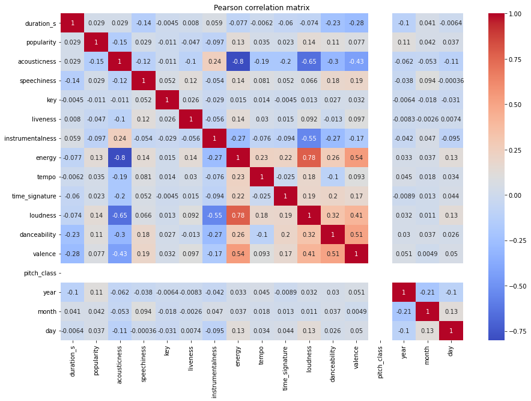

```python
# create heatmap for correlation
plt.figure(figsize=(15, 10))
corr = liked_songs_clean.corr()
sns.heatmap(corr, annot=True, cmap="coolwarm").set_title('Pearson correlation matrix')
plt.show()
```

Correlation values range from -1 to 1. The closer a correlation value is to 1 (positive or negative), the stronger the correlation between the two variables. Variables with a strong positive correlation increase together, whereas variables with a strong negative correlation experience opposing polarization (as one goes up, the other goes down and vice versa). The closer the correlation is to 0, the weaker the correlation.

- variables will always have a correlation of 1 with themselves
- we can see the strongest correlation is between `energy` and `acousticness` at -0.8.
- the weakest correlation is between `speechiness` and `dat` at -0.00036

```python
# we can also create a pairplot of the correlations
sns.pairplot(liked_songs_clean)
```

[output not shown]

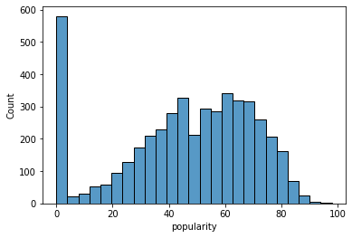

```python
# create a histogram of the popularity of the tracks
sns.histplot(data=liked_songs_clean, x="popularity", bins=25);
```

This is just a visual confirmation of how popular my music tastes are. The majority of my music tastes fall in the mid-range

```python
# mean popularity score value
liked_songs_clean.popularity.mean()
```

```
46.128714988240326
```

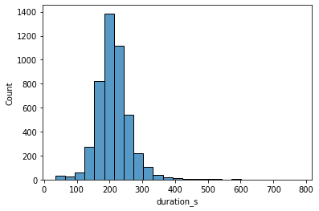

```python
# histogram of duration in seconds
sns.histplot(liked_songs_clean.duration_s, bins=25);
```

```python
(liked_songs_clean.duration_s.mean())/60
```

```
3.53242311667023
```

Most of my saved songs are around 3 minutes long.

```python
# longest song in my saved
liked_songs_clean.iloc[ liked_songs_clean['duration_s'].idxmax() ][['artists','name']]
```

```
artists    Garth Stevenson
name                  Dawn
Name: 4384, dtype: object
```

```python
# shortest song in my saved
liked_songs.iloc[liked_songs['duration_s'].idxmin() ][['artists','name']]
```

```
artists       Bo Burnham
name       Unpaid Intern
Name: 1233, dtype: object
```

```python
# liked_songs_clean.pitch_class.value_counts()
# sns.countplot(data = liked_songs_clean,
#               x = 'pitch_class',
#               order = liked_songs_clean.pitch_class.value_counts().index)

# plt.xticks(rotation=70);
```

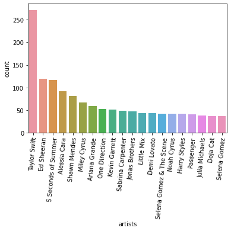

```python
sns.countplot(data=liked_songs_clean, x='artists', order=liked_songs_clean.artists.value_counts()[:20].index);

plt.xticks(rotation=85);
```

Okay, but what about if we group by year

```python
liked_songs_2022 = liked_songs_clean[liked_songs_clean.year > 2021]
print(str(len(liked_songs_2022)) + " songs have been added in 2022 so far")
```

```
796 songs have been added in 2022 so far
```

```python
liked_songs_2022.head(5)
```

|  | id | name | artists | duration_s | popularity | added_at | acousticness | speechiness | key | liveness | ... | time_signature | loudness | danceability | valence | genre_list | genre | pitch_class | year | month | day |
| --- | --- | --- | --- | --- | --- | --- | --- | --- | --- | --- | --- | --- | --- | --- | --- | --- | --- | --- | --- | --- | --- |
| 0 | 5GUYJTQap5F3RDQiCOJhrS | Self Control | Frank Ocean | 249.667 | 76 | 2022-10-08 03:33:49+00:00 | 0.7680 | 0.0321 | 8 | 0.3690 | ... | 4 | -10.426 | 0.581 | 0.452 | ['hip hop', 'lgbtq+ hip hop', 'neo soul', 'pop'] | hip hop | NaN | 2022 | 10 | 8 |
| 1 | 7lagLMBTqqOkta5eqRfNXc | Every Beginning Ends | Noah Cyrus | 150.491 | 61 | 2022-10-08 03:33:47+00:00 | 0.6300 | 0.0277 | 3 | 0.1090 | ... | 3 | -9.930 | 0.627 | 0.390 | ['pop', 'post-teen pop'] | pop | NaN | 2022 | 10 | 8 |
| 2 | 1NZLDZsqmvMVcZ02VT7ocP | Heaven | Bazzi | 153.391 | 67 | 2022-10-08 03:33:36+00:00 | 0.1400 | 0.0350 | 5 | 0.0560 | ... | 4 | -5.515 | 0.798 | 0.683 | ['dance pop', 'electropop', 'pop'] | dance pop | NaN | 2022 | 10 | 8 |
| 3 | 252G7yirQ4pXj6ZD4T9R2W | Mona Lisa, Mona Lisa | FINNEAS | 172.111 | 64 | 2022-10-08 03:33:35+00:00 | 0.0252 | 0.0441 | 0 | 0.5810 | ... | 4 | -6.844 | 0.742 | 0.646 | ['alt z', 'electropop', 'la indie', 'pop'] | alt z | NaN | 2022 | 10 | 8 |
| 4 | 4MXE6VCvTsQitHWrAxj7Kg | Maple Syrup | The Backseat Lovers | 243.529 | 72 | 2022-10-08 03:33:33+00:00 | 0.0447 | 0.0582 | 2 | 0.0778 | ... | 3 | -9.703 | 0.543 | 0.384 | ['indie pop', 'modern rock', 'slc indie'] | indie pop | NaN | 2022 | 10 | 8 |

5 rows × 23 columns

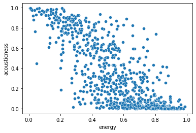

```python
sns.scatterplot(data=liked_songs_2022, x='energy', y='acousticness');
```

Above is the visualization of we saw earlier in the heatmap. As energy increases, the amount of acousticness the song has tends to decrease. And we can fit this with linear regression to point out an even cleaner pattern.

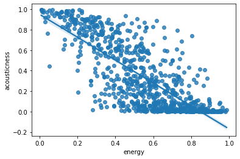

```python
sns.regplot(data=liked_songs_2022, x='energy', y='acousticness');
```

How have the audio features of my song choices changed over time? We can write a time series function to plot the change of our data over timie

```python
def plot_time_series(col_name, title, rolling_window_days):
    daily_series = pd.Series(data=np.array(liked_songs_clean[col_name]),
                                      name=col_name,
                                      index=liked_songs_clean['added_at']).sort_index()

    (daily_series.rolling(window = rolling_window_days)
     .mean()
     .plot(figsize=(30, 10))
     .set(xlabel='date (by day)', ylabel=col_name, title=title))

    plt.show()
```

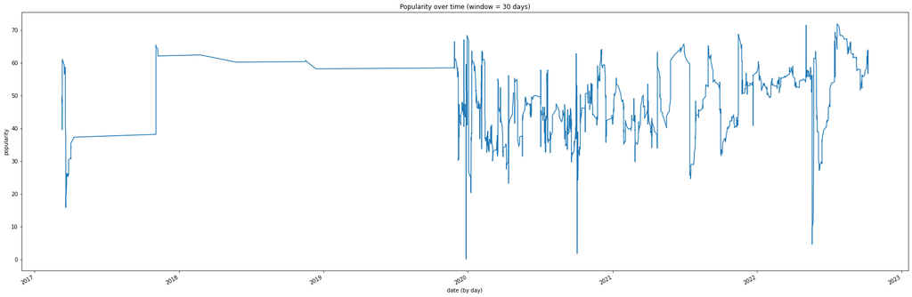

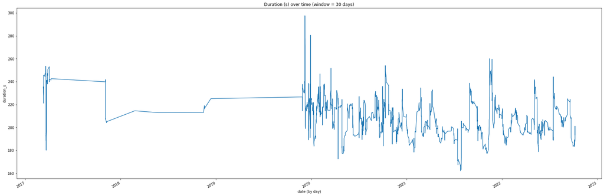

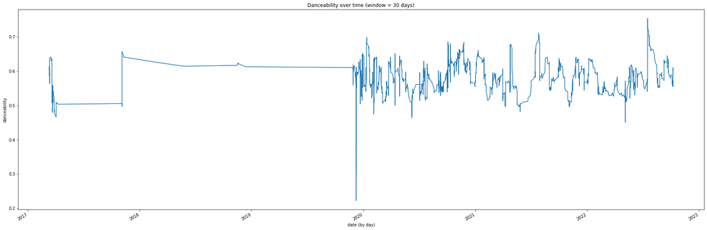

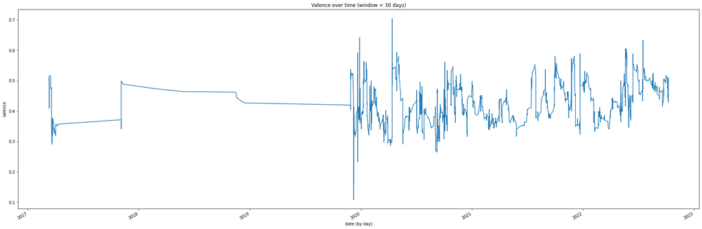

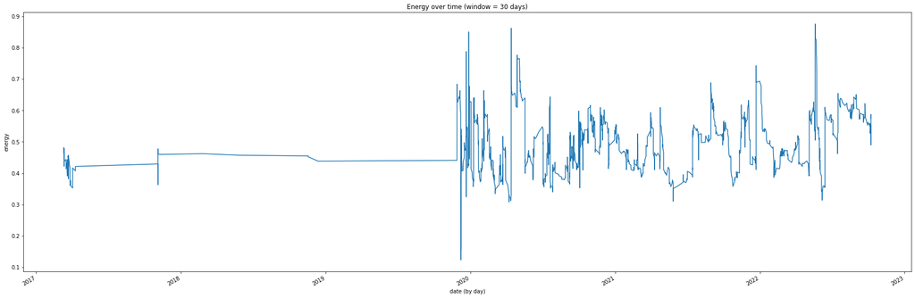

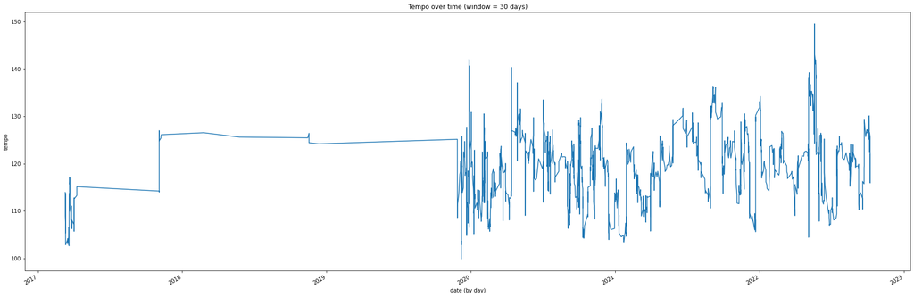

```python
plot_time_series('popularity', 'Popularity over time (window = 30 days)', 30)
plot_time_series('duration_s', 'Duration (s) over time (window = 30 days)', 30)
plot_time_series('danceability', 'Danceability over time (window = 30 days)', 30)
plot_time_series('valence', 'Valence over time (window = 30 days)', 30)
plot_time_series('energy', 'Energy over time (window = 30 days)', 30)
plot_time_series('tempo', 'Tempo over time (window = 30 days)', 30)
```

In general, our plots above are fairly stationary from 2020 on. However, they could be a lot better.

We can also look at the change in the number of songs added over time.

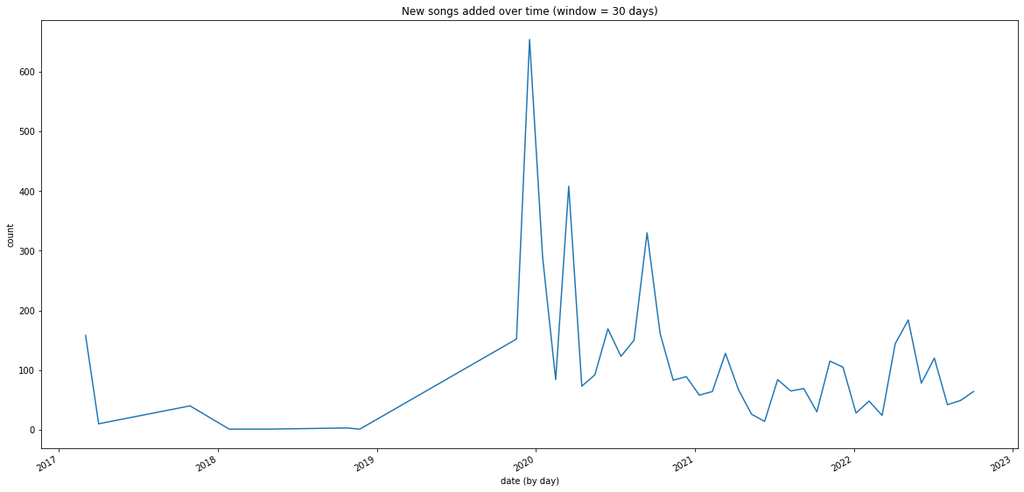

```python
songs_added_in_window = (liked_songs_clean.groupby([pd.Grouper(freq='30D', key='added_at'), 'id'])
                         .size().reset_index(name='count').groupby('added_at').count()['count'])

(songs_added_in_window
 .plot(figsize=(20, 10))
 .set(xlabel='date (by day)', ylabel='count', title='New songs added over time (window = 30 days)'))

plt.show()
```

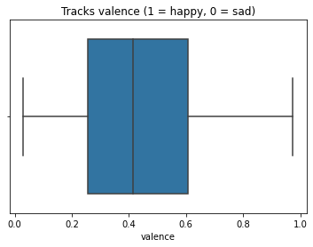

```python
# plt.figure(figsize=(15, 10))
sns.boxplot(x=liked_songs_clean['valence']).set_title('Tracks valence (1 = happy, 0 = sad)')
plt.show()
```

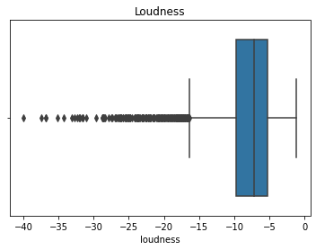

```python
# plt.figure(figsize=(15, 10))
sns.boxplot(x=liked_songs_clean['loudness']).set_title('Loudness')
plt.show()
```

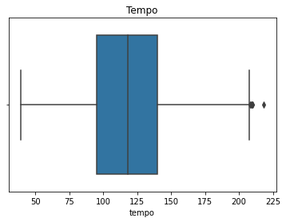

```python
# plt.figure(figsize=(15, 10))
sns.boxplot(x=liked_songs_clean['tempo']).set_title('Tempo')
plt.show()
```

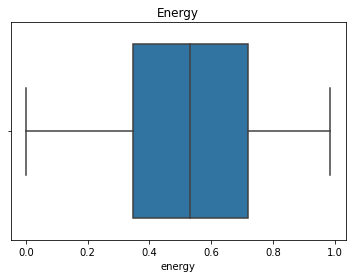

```python
# plt.figure(figsize=(15, 10))
sns.boxplot(x=liked_songs_clean['energy']).set_title('Energy')
plt.show()
```

Further visualization:

1. change in the number of songs I've added for particular artists as the years go by  
   a. have I added more Taylor Swift recently? less?  
   b. are the any new artists that have popped up for me?
2. which months I tend to add the most songs in
3. ...

There's definitely room for further exploration and visualization